# Investigating a Dataset

- Introduction
- Data Preprocessing
- Exploratory Data Analysis
- Observations & Key Findings
- Limitations
- References

## Introduction

For this dataset investigation, we will be using dataset obtained from The Movie Database (TMDb). The dataset contains information about 10,000 movies from 1960-2015. Also, "budget_adj" and "revenue_adj" are columns representing values that are adjusted to 2010 dollars.

## Data Preprocessing

```python
#Import libraries
import pandas as pd
import numpy as np
import matplotlib.pyplot as plt
import seaborn as sns

%matplotlib inline
```

```python
#Import dataset
df = pd.read_csv('tmdb-movies.csv')
#Show no. of rows & columns
df.shape
```

```
(10866, 21)
```

```python
#Show first row
df.head(1)
```

|  | id | imdb_id | popularity | budget | revenue | original_title | cast | homepage | director | tagline | ... | overview | runtime | genres | production_companies | release_date | vote_count | vote_average | release_year | budget_adj | revenue_adj |
| --- | --- | --- | --- | --- | --- | --- | --- | --- | --- | --- | --- | --- | --- | --- | --- | --- | --- | --- | --- | --- | --- |
| 0 | 135397 | tt0369610 | 32.985763 | 150000000 | 1513528810 | Jurassic World | Chris Pratt\|Bryce Dallas Howard\|Irrfan Khan\|Vi... | http://www.jurassicworld.com/ | Colin Trevorrow | The park is open. | ... | Twenty-two years after the events of Jurassic ... | 124 | Action\|Adventure\|Science Fiction\|Thriller | Universal Studios\|Amblin Entertainment\|Legenda... | 6/9/15 | 5562 | 6.5 | 2015 | 1.379999e+08 | 1.392446e+09 |

1 rows × 21 columns

#### Irrelevant Features Dropped

Features listed below that we think are not useful to us are dropped:  
'id'  
'imbdb_id'  
'popularity'  
'homepage'  
'tagline'  
'keywords'  
'overview'

*'budget' & 'revenue'* will also be dropped as 'budget_adj' & 'revenue_adj' are similar features which are adjusted to 2010 Dollars which will provide better consistency for our analysis.

```python
#Drop irrelevant columns
df.drop(columns=['keywords','homepage','overview','tagline','id','imdb_id','popularity','budget','revenue'],inplace=True)
```

#### Renaming Columns

This step will make it easier for us conduct our analysis.

```python
#Renaming Columns
df.rename(columns=
        {
    "original_title"       : "title",
    "release_date"         : "date",
    "release_year"         : "year",
    "budget_adj"           : "budget",
    "revenue_adj"          : "revenue",
    "production_companies" : "companies",
        },
         inplace=True)

#Show column names
df.columns
```

```
Index(['title', 'cast', 'director', 'runtime', 'genres', 'companies', 'date',
       'vote_count', 'vote_average', 'year', 'budget', 'revenue'],
      dtype='object')
```

```python
df.head(1)
```

|  | title | cast | director | runtime | genres | companies | date | vote_count | vote_average | year | budget | revenue |
| --- | --- | --- | --- | --- | --- | --- | --- | --- | --- | --- | --- | --- |
| 0 | Jurassic World | Chris Pratt\|Bryce Dallas Howard\|Irrfan Khan\|Vi... | Colin Trevorrow | 124 | Action\|Adventure\|Science Fiction\|Thriller | Universal Studios\|Amblin Entertainment\|Legenda... | 6/9/15 | 5562 | 6.5 | 2015 | 1.379999e+08 | 1.392446e+09 |

#### Duplicate entries

```python
#Number of duplicate entries
df.duplicated().sum()
```

```
1
```

```python
#Drop duplicate rows
df.drop_duplicates(inplace=True)
```

#### Incorrect Data Types & Missing Values

```python
df.info()
```

```
<class 'pandas.core.frame.DataFrame'>
Int64Index: 10865 entries, 0 to 10865
Data columns (total 12 columns):
title           10865 non-null object
cast            10789 non-null object
director        10821 non-null object
runtime         10865 non-null int64
genres          10842 non-null object
companies       9835 non-null object
date            10865 non-null object
vote_count      10865 non-null int64
vote_average    10865 non-null float64
year            10865 non-null int64
budget          10865 non-null float64
revenue         10865 non-null float64
dtypes: float64(3), int64(3), object(6)
memory usage: 1.1+ MB
```

```python
#Converting date datatype to datetime format
df['date'] = pd.to_datetime(df['date'])
```

```python
#Show missing entries in descending order
df.isnull().sum().sort_values(ascending=False)
```

```
companies       1030
cast              76
director          44
genres            23
revenue            0
budget             0
year               0
vote_average       0
vote_count         0
date               0
runtime            0
title              0
dtype: int64
```

*Cast, Director, and Genres* have number of entries that are insignificant and will be dropped. On the other hand, *'companies'* has 1030 entries which represent roughly 10% of our dataset. If we were to drop rows with missing entries from *'companies'*, we will be losing information from other features that might affect our analysis. In any case, we will just drop them anyway for the sake of not overcomplicating our preprocessing stage.

```python
#Drop entries with null values
df.dropna(inplace=True)
```

#### Checking the *'date' & 'year'* variables

While conducting this analysis, we noticed that the year from the *'date'* column do not always match with those in the *'year'* column. Let's find out how many are incorrect.

```python
#Show 'date' & 'year' column from the last 10 rows
df[['date','year']].tail(10)
```

|  | date | year |
| --- | --- | --- |
| 10856 | 2066-02-16 | 1966 |
| 10857 | 2066-06-10 | 1966 |
| 10858 | 2066-05-25 | 1966 |
| 10859 | 2066-10-05 | 1966 |
| 10860 | 2066-05-20 | 1966 |
| 10861 | 2066-06-15 | 1966 |
| 10862 | 2066-12-21 | 1966 |
| 10863 | 2066-01-01 | 1966 |
| 10864 | 2066-11-02 | 1966 |
| 10865 | 2066-11-15 | 1966 |

```python
#Check if both the year values from 'date' and 'year' that ARE NOT EQUAL
wrong_year = df['date'].dt.year != df['year']
#Number of entries with the year not match
sum(wrong_year)
```

```
347
```

It seems that the last two digits of both the year value are correct. Let's verify this.

```python
#Check if both the last two digits are the same
date_year = df.date.dt.year.astype(str).str[2:4]
year_year = df.year.astype(str).str[2:4]
#Show the number of incorrect match of the last two digits from the two columns.
sum(date_year != year_year)
```

```
0
```

Now we know that both last two digits from either two columns are perfectly matched, we can fix this. The dates and years tell us when the movies were being released. And since the year 2066, which is the future, can be found from the *'date'* column, we will use the year value from the *'year'* column to replace those in the *'date'* column.

```python
#Extract the first two digit of the year in 'date'
date_first_two = df['date'].dt.year.astype(str).str[:2]

#Show the first two digit of the year in 'year'
year_first_two = df['year'].astype(str).str[:2]

#Replace the first two digit of the year value in the 'date' column if it doesnt match the year..
#..with those from the'year' column
century = date_first_two.mask(date_first_two != year_first_two, year_first_two)

#extract the date value without the first two digits of the year
date_val = df['date'].astype(str).str[-8:]

#Update relase_date column
df['date'] = century + date_val

#Convert back to datetime datatype
df['date'] = pd.to_datetime(df['date'])
```

```python
#Verify that there are no more incorrect century values from 'date' column
sum(df['date'].dt.year != df['year'])
```

```
0
```

#### Creation of new *'month' & 'profit'* column

```python
#The month in which movies were released are extracted from the 'date' column
df['month'] = df['date'].dt.month

#Profit can be calculated by revenue minus budget
df['profit'] = df['revenue'] - df['budget']
```

```python
#Setting index by 'date'
df.set_index('date',inplace=True)
df.sort_index(ascending=True,inplace=True)
```

### Descriptive Statistics

```python
#Descriptive Statistics
df.describe()
```

|  | runtime | vote_count | vote_average | year | budget | revenue | month | profit |
| --- | --- | --- | --- | --- | --- | --- | --- | --- |
| count | 9772.000000 | 9772.000000 | 9772.000000 | 9772.000000 | 9.772000e+03 | 9.772000e+03 | 9772.000000 | 9.772000e+03 |
| mean | 102.926627 | 239.312014 | 5.963528 | 2000.878428 | 1.941599e+07 | 5.705309e+07 | 6.875358 | 3.763710e+07 |
| std | 27.877432 | 603.011504 | 0.913174 | 13.036794 | 3.566634e+07 | 1.514499e+08 | 3.410691 | 1.314756e+08 |
| min | 0.000000 | 10.000000 | 1.500000 | 1960.000000 | 0.000000e+00 | 0.000000e+00 | 1.000000 | -4.139124e+08 |
| 25% | 90.000000 | 18.000000 | 5.400000 | 1994.000000 | 0.000000e+00 | 0.000000e+00 | 4.000000 | 0.000000e+00 |
| 50% | 100.000000 | 46.000000 | 6.000000 | 2005.000000 | 3.061342e+05 | 0.000000e+00 | 7.000000 | 0.000000e+00 |
| 75% | 112.000000 | 173.000000 | 6.600000 | 2011.000000 | 2.464268e+07 | 4.311848e+07 | 10.000000 | 2.029698e+07 |
| max | 877.000000 | 9767.000000 | 8.700000 | 2015.000000 | 4.250000e+08 | 2.827124e+09 | 12.000000 | 2.750137e+09 |

```python
#Droping budget & revenue with zero value entries.
df = df[df['budget'] != 0]
df = df[df['revenue'] != 0]

#Convert units of budget & revenue to Million Dollar Unit
df['budget'] = df['budget']/1e6
df['revenue'] = df['revenue']/1e6
df['profit'] = df['profit']/1e6
```

```python
df.info()
```

```
<class 'pandas.core.frame.DataFrame'>
DatetimeIndex: 3805 entries, 1960-06-15 to 2015-12-30
Data columns (total 13 columns):
title           3805 non-null object
cast            3805 non-null object
director        3805 non-null object
runtime         3805 non-null int64
genres          3805 non-null object
companies       3805 non-null object
vote_count      3805 non-null int64
vote_average    3805 non-null float64
year            3805 non-null int64
budget          3805 non-null float64
revenue         3805 non-null float64
month           3805 non-null int64
profit          3805 non-null float64
dtypes: float64(4), int64(4), object(5)
memory usage: 416.2+ KB
```

After much data preprocessing, the total remaining entries are now 3805 which equates to a 65% reduction from our initial entries of 10866.

## Exploratory Data Analysis

For this part, we will be looking at the overall distributon of the data to further our understanding and insights into our data and seeking answers to our questions.

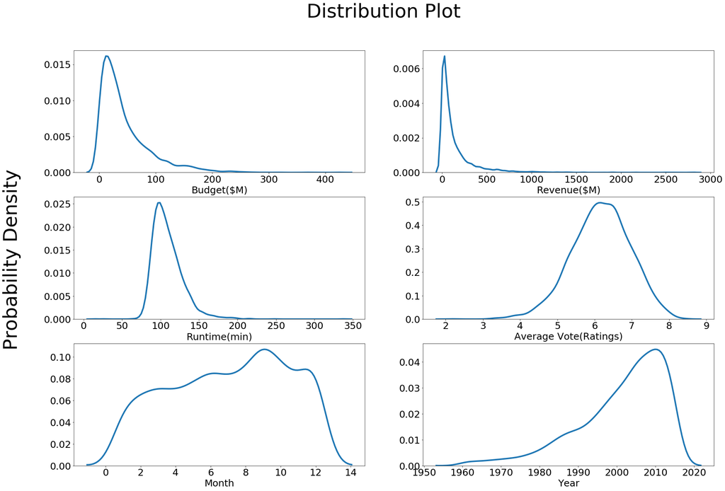

```python
#Overview of dataset distribution
fig, axes = plt.subplots(nrows=3,ncols=2,figsize=(30,20))

dist_plot = [df.budget,df.revenue,df.runtime,df.vote_average,df.month,df.year]
xlbl = ['Budget($M)','Revenue($M)','Runtime(min)','Average Vote(Ratings)','Month','Year']

for i, ax, xlbl in zip(dist_plot, axes.flat,xlbl):
    ax_plot = sns.distplot(i, hist=False,kde_kws={'linewidth': 4}, ax=ax)
    ax_plot.set_xlabel(xlbl,fontsize=25)
    ax_plot.tick_params(axis = 'both', labelsize = 25)

fig.text(0.05,0.5, "Probability Density", ha="center", va="center", rotation=90,fontsize=50)
fig.text(0.5,0.95, "Distribution Plot", ha="center", va="center",fontsize=50)
plt.show()
```

### Is the movie industry profitable?

To help answer this question, we will be plotting both budget and revenue (both adjusted to 2010 dollars) for movies released from 1960 - 2015. In the graph below, the budget plot seems to stay somewhat constant while movies released from 1960 to around 1980 tend to generate higher revenues than years beyond 1980. Could it be that the number of movies released have risen over the years that may have caused this?

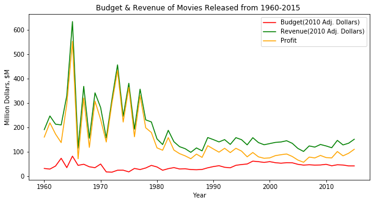

```python
#Plotting the yearly means for budget and revenue
fig, ax = plt.subplots(figsize=(10,5))
ax.plot(df.groupby('year')['budget'].mean(),color='r')
ax.plot(df.groupby('year')['revenue'].mean(),color='g');
ax.plot(df.groupby('year')['profit'].mean(),color='orange');
plt.xlabel('Year')
plt.ylabel('Million Dollars, $M')
plt.legend(labels=['Budget(2010 Adj. Dollars)','Revenue(2010 Adj. Dollars)','Profit'])
plt.title('Budget & Revenue of Movies Released from 1960-2015 ')

plt.show()
```

We can see that the number of movies released have increased dramatically during this period. This could be one possible factor that may caused the revenues to drop. Nevertheless, the revenue plot is still greater than the budget plot and hence, the movie industry is still profitable.

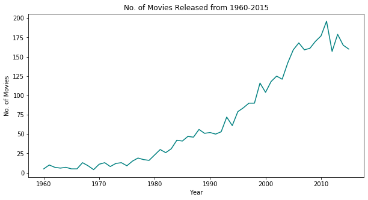

```python
fig, ax = plt.subplots(figsize=(10,5))
ax.plot(df.groupby('year')['budget'].count(),color='teal')
plt.xlabel('Year')
plt.ylabel('No. of Movies')
plt.title('No. of Movies Released from 1960-2015')
plt.show()
```

### Which month have the most releases?

September and December have the most releases while January has the lowest.

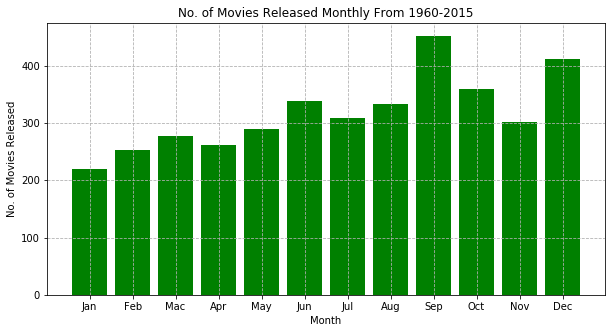

```python
x = np.arange(12)
money = df.groupby('month')['month'].count()

fig, ax = plt.subplots(figsize=(10,5))
plt.bar(x, money,color='green')
plt.xticks(x, ('Jan', 'Feb', 'Mac', 'Apr','May','Jun','Jul','Aug','Sep','Oct','Nov','Dec'))
plt.xlabel('Month')
plt.ylabel('No. of Movies Released')
plt.title('No. of Movies Released Monthly From 1960-2015')
plt.grid(linestyle='--')
plt.show()
```

### What does the genre statistics look like?

```python
def splitDataFrameList(genres,target_column,separator):

    def splitListToRows(row,row_accumulator,target_column,separator):
        split_row = row[target_column].split(separator)
        for s in split_row:
            new_row = row.to_dict()
            new_row[target_column] = s
            row_accumulator.append(new_row)
    new_rows = []
    df.apply(splitListToRows,axis=1,args = (new_rows,target_column,separator))
    new_df = pd.DataFrame(new_rows)
    return new_df
```

```python
genres = splitDataFrameList(df,'genres',"|")
genres = genres.groupby('genres')['genres'].count().sort_values(ascending=False)
```

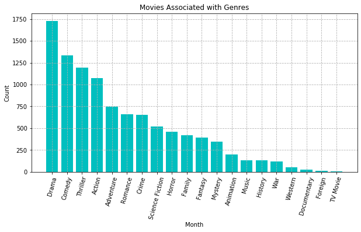

```python
x = np.arange(len(genres))

labels = genres.index

fig, ax = plt.subplots(figsize=(10,5))
plt.bar(x, genres,color='c')
plt.xticks(x, labels,rotation=75)
plt.xlabel('Month')
plt.ylabel('Count')
plt.title('Movies Associated with Genres')
plt.grid(linestyle='--')
plt.show()
```

### Do longer movies obtain higher ratings?

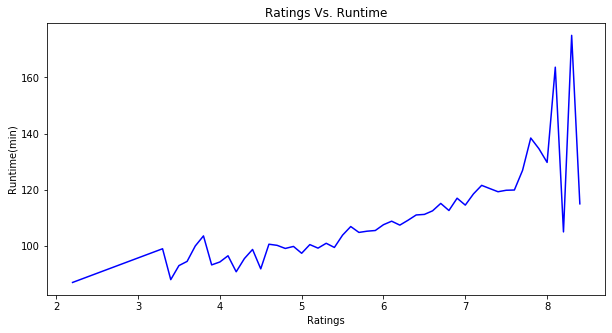

```python
fig, ax = plt.subplots(figsize=(10,5))
ax.plot(df.groupby('vote_average')['runtime'].mean(),color='b')
plt.ylabel('Runtime(min)')
plt.xlabel('Ratings')
plt.title('Ratings Vs. Runtime')
plt.show()
```

### Which companies produced quality movies?

We can first look at the top 20 production companies by number of movies released and revenues.

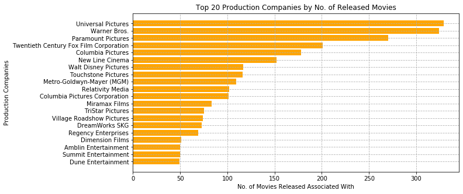

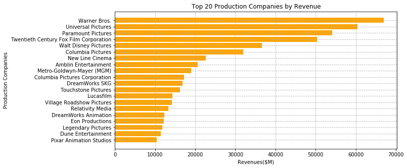

```python
com_count = splitDataFrameList(df,'companies',"|")
com_count = com_count.companies.value_counts(ascending=False).head(20)

x = np.arange(len(com_count))
com_count.sort_values(ascending=True,inplace=True)
labels = com_count.index

#Top 20 Production Companies by No. of Released Movies Plot
fig, ax = plt.subplots(figsize=(10,5))
plt.barh(x, com_count,color='orange')
plt.yticks(x, labels,rotation=0)
plt.xlabel('No. of Movies Released Associated With')
plt.ylabel('Production Companies')
plt.title('Top 20 Production Companies by No. of Released Movies')
plt.grid(linestyle='--')
plt.show()

com_rev = splitDataFrameList(df,'companies',"|")
com_rev = com_rev.groupby('companies')['revenue'].sum().sort_values(ascending=False).head(20)

x = np.arange(len(com_rev))
com_rev.sort_values(ascending=True,inplace=True)
labels = com_rev.index

#Top 20 Production Companies by Revenue Plot
fig, ax = plt.subplots(figsize=(10,5))
plt.barh(x, com_rev,color='orange')
plt.yticks(x, labels,rotation=0)
plt.xlabel('Revenues($M)')
plt.ylabel('Production Companies')
plt.title('Top 20 Production Companies by Revenue')
plt.grid(linestyle='--')
plt.show()
```

By comparing both graphs above, companies that produced more movies tend to generate higher revenues. But this do not tell us whether companies are actually producing good or bad movies. Given that user ratings are unreliable, one way to tell whether a company produces good movies is by finding the ratio of the amount of revenue generated per movie released.

We will be using the top 20 companies by revenue to further analyze their individual ratio of the amount revenue generated per movie release.

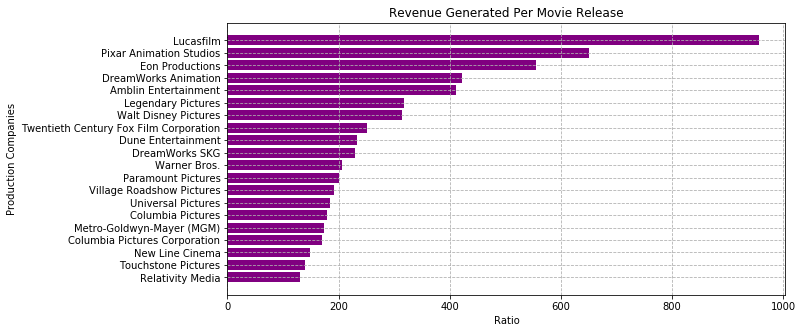

```python
com = splitDataFrameList(df,'companies',"|")
com_20 = com.groupby('companies')['revenue'].sum().sort_values(ascending=False).head(20)


ratio_20 = []

for a,b in zip(com_20.index,range(len(com_20))):
    #Production Company Total Revenue / Total Movie Released by Production Company
    ratio = com_20.values[b] / com.loc[com['companies'] == a].count()['companies']
    ratio_20 = np.append(ratio_20,ratio)

ratio_df = pd.DataFrame(data=ratio_20,index=com_20.index)
ratio_df.sort_values(by=0,ascending=True,inplace=True)

#Revenue Generated Per Movie Release Plot
fig, ax = plt.subplots(figsize=(10,5))
plt.barh(ratio_df.index, ratio_df.iloc[:,0],color='purple')
plt.xlabel('Ratio')
plt.ylabel('Production Companies')
plt.title('Revenue Generated Per Movie Release')
plt.grid(linestyle='--')
plt.show()
```

Lucasfilm, Pixar Animation Studios and Eon productions are the top three that have the highest amount of revenue generated per title release. This indicate that much more people have watched their films produced by these companies as compared to the rest which further implies that they produced excellent quality films.

**Top 10 Directors**

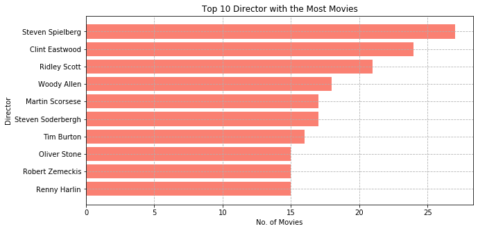

```python
dtor = df.director.value_counts(ascending=False).head(10)
dtor.sort_values(ascending=True,inplace=True)

#Top 10 Director with the Most Movies Plot
fig, ax = plt.subplots(figsize=(10,5))
plt.barh(dtor.index, dtor,color='salmon')
plt.xlabel('No. of Movies')
plt.ylabel('Director')
plt.title('Top 10 Director with the Most Movies')
plt.grid(linestyle='--')
plt.show()
```

**Top 10 Cast**

```python
cast = splitDataFrameList(df,'cast',"|")
cast = cast.groupby('cast')['cast'].count().sort_values(ascending=False).head(10)
```

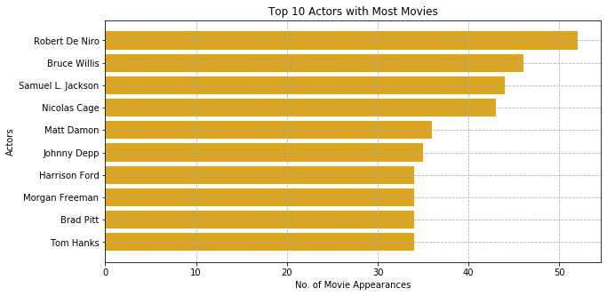

```python
x = np.arange(len(cast))
cast.sort_values(ascending=True,inplace=True)
labels = cast.index

#Top 10 Actors with Most Movies Plot
fig, ax = plt.subplots(figsize=(10,5))
plt.barh(x, cast,color='goldenrod')
plt.yticks(x, labels,rotation=0)
plt.xlabel('No. of Movie Appearances')
plt.ylabel('Actors')
plt.title('Top 10 Actors with Most Movies')
plt.grid(linestyle='--')
plt.show()
```

## Observations & Key Findings

The movie industry remains profitable despite lower profit margain in recent years with the increased number of movies being released.

#### *Note: All observations and findings are provisional and not final.(see limitations)*

## Limitations

2)Initially, there are 10866 entries in the dataset. After preprocessing, the number of entries fell to 3805 entries. That is a 65% reduction in the number of entries compared to the original dataset.

3)Vote average feature is unreliable when factored in the number of vote count distribution.

4)There are some overlap production companies that are owned by one company. *(eg. Lucasfilm, Pixar, 21st Century Fox are owned by Disney)*

## References

https://www.themoviedb.org  
https://matplotlib.org/gallery/ticks_and_spines/custom_ticker1.html#sphx-glr-gallery-ticks-and-spines-custom-ticker1-py  
https://gist.github.com/jlln/338b4b0b55bd6984f883  
https://pandas.pydata.org/pandas-docs/stable/reference/api/pandas.DataFrame.html  
https://matplotlib.org/3.1.1/api/_as_gen/matplotlib.pyplot.bar.html  
https://matplotlib.org/3.1.0/gallery/color/named_colors.html  
https://en.wikipedia.org/wiki/List_of_Disney_acquisitions  
https://matplotlib.org/3.1.0/api/_as_gen/matplotlib.pyplot.text.html